# Activity: Street or Road?

Guilherme Lima

## Load in the data

```r
#load libraries
library(tidyverse)
#load in the data here
# we will only be using the "street-addresses.csv" file from the text
download.file(url="https://mdbeckman.github.io/dcSupplement/data/CMS_ProvidersSimple.rds",
              destfile = "Your-Name-For-The-File.rds")
DataTable <- readRDS("Your-Name-For-The-File.rds")
```

## Recreate Solved Example using `sample(50)`

```r
Addresses <- read_csv("https://mdbeckman.github.io/dcSupplement/data/street-addresses.csv")
Sample <-
  Addresses %>%
  sample_n(size = 50)

SampleMatches <-
  Sample %>%
  filter(grepl(pattern = "PO", address))

SampleDont <-
  Sample %>%
  filter( !grepl(pattern = "PO", address))

pattern <- "BOX\\s+(\\d+)"

SampleMatches <-
  Sample %>%
  filter(grepl(pattern, address))

SampleDont <-
  Sample %>%
  filter( !grepl(pattern, address))

SampleDont
```

| address |
| --- |
| 3737 GLENWOOD AVENUE STE 100 |
| 1101 LINDEN CREST ROAD |
| 224 S BLOUNT ST |
| 113 FOUNTAIN RIDGE PLACE |
| 4112 O'BRIANT PL |
| 12008 N EXETER WAY |
| 128 E HARGETT ST |
| 8303 RUBBLESTONE PATH |
| 1814 CARMEL RD |
| 1348 BOZEMAN LOOP |

[output cut: 2 more lines]

```r
SampleBoxNumbers <-
  Sample %>%
  filter(grepl(pattern, address)) %>%
  tidyr::extract(address, into = "boxnum", regex = pattern)
```

## Recreate Soved Example using the entire `Address` data set

```r
AddressMatches <-
  Addresses %>%
  filter(grepl(pattern = "PO", address))

AddressDont <-
  Addresses %>%
  filter( !grepl(pattern = "PO", address))

pattern <- "BOX\\s+(\\d+)"

AddressMatches <-
  Addresses %>%
  filter(grepl(pattern, address))

AddressDont <-
  Addresses %>%
  filter( !grepl(pattern, address))

AddressDont
```

| address |
| --- |
| 2117 MARINER CIRCLE |
| 101 EPPING WAY |
| 5102 ECHO RIDGE RD |
| 5007 PURITAN RD |
| 04-I ROBIN CIRCLE |
| 4800 WESTERN BLVD |
| NCSU B0X 15637 |
| 2801 NELLOWOOD ST |
| 237 LARCHMONT ROAD |
| 2114 ORCHARD CT |

[output cut: 990 more lines]

```r
AddressBoxNumbers <-
  Addresses %>%
  filter(grepl(pattern, address)) %>%
  tidyr::extract(address, into = "boxnum", regex = pattern)
```

#### Additional Question: How many addresses are a PO BOX (including NCSU BOX)?

```r
AddressBoxNumbers %>% summarise(count = n())
```

| count |
| --- |
| 11100 |

```r
NA
```

My answer here…… 11100

## Back to the Streets: Your Turn

#### Part 1: Explain (in english) each line of the following code chunk

```r
pattern <- "(ST|RD|ROAD)"
#a string indicating an exact pattern match
LeftOvers <-
#assign the variable LeftOvers
  Addresses %>%
#from the Addresses table, use the chaining operator
  filter( !grepl(pattern, address),
#filters addresses for ones that do not match the pattern
          !grepl("\\sAPT|UNIT\\s[\\d]+$", address),

          !grepl(" BOX ", address)

          )
#closes the filter function
```

My answer here……. 1) a string indicating an exact pattern match 2) assign the variable LeftOvers 3) from the Addresses table, use the chaining operator 4) filters addresses for ones that do not match the pattern 5) filters addresses for ones that do not contain APT or UNIT (followed by the number at the end)  
6) filters addresses for ones that do not contain BOX  
7) closes the filter function

#### Part 2: Implement your method on the entire `Addresses` data set. Explain how your code works line by line.

```r
pattern <- "(ST|RD|ROAD|CIRCLE|WAY|TRAIL|LN|DR|CIR|AVE|PKWY|COURT|POINT|BLVD|CT|LANE|PL|PATH|LOOP)"
#1
LeftOvers <-
#2
  Addresses %>%
#3
  filter( !grepl(pattern, address),
#4
          !grepl("\\sAPT|UNIT\\s[\\d]+$", address),
#5
          !grepl("BOX|BX|B0X", address),
#6
          !grepl("HOSPITAL", address))
#7
head(LeftOvers)
```

| address |
| --- |
| 130 THE WINERY |
| HMIA-267 |
| 1104 PULLEN HALL |
| 311 BAREFOOT |
| 512 LIVE OAK |
| 1706 WINGATE UNIVERSITY |

```r
NA
```

My answer here…….

1. identifies common street endings and applies them to a pattern string
2. assign the variable LeftOvers
3. from the Addresses table, use the chaining operator
4. filters addresses for ones that do not match the pattern
5. filters addresses for ones that do not contain APT or UNIT (followed by the number at the end)
6. filters addresses for ones that do not contain BOX
7. filters addresses for ones that do not contain HOSPITAL, since hospital is a place and not a street ending

#### Additional Question 1: Present your result from part 2 by providing a table in descending order of popularity for the street name endings you found

```r
pattern <- "(ST|RD|ROAD|CIRCLE|WAY|TRAIL|LN|DR|CIR|AVE|PKWY|COURT|POINT|BLVD|CT|LANE|PL|PATH|LOOP)"
StreetEnding <- Addresses %>% filter(grepl(pattern,address)) %>% tidyr::extract(address, into = "ending", regex = pattern) %>% group_by(ending) %>% summarise(count = n()) %>%  arrange(desc(count))
head(StreetEnding)
```

| ending | count |
| --- | --- |
| ST | 902 |
| DR | 753 |
| RD | 747 |
| AVE | 270 |
| CT | 214 |
| ROAD | 188 |

#### Additional Question 2: Present your result by using ggplot to a bar chart in descending order of popularity for the street name endings you found previously.

Note: make sure your order street names according to popularity, not alphabetically.

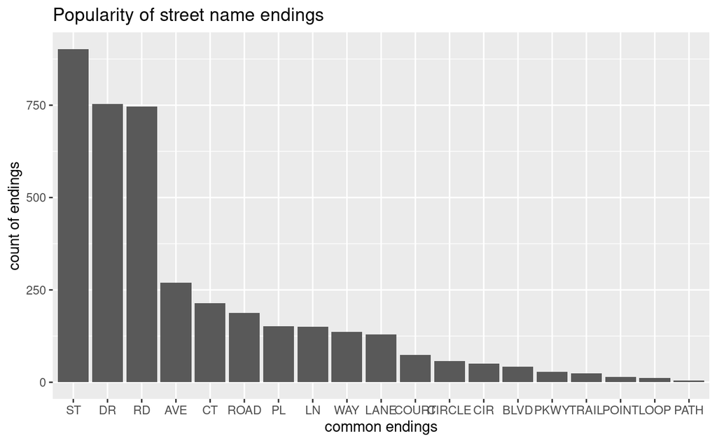

```r
ggplot(StreetEnding, aes(x = reorder(ending,-count), y = count)) +
  geom_bar(stat="identity") + labs(x = "common endings", y= "count of endings", title = "Popularity of street name endings")
```

#### Additional Question 3: Comment on any patterns you see

My answer here…….

The top 5 most common endings from the selected pattern are: ST,DR,RD,AVE,CT in order from greatest count of endings to lowest. ST,DR,RD by have a much greater number of counts than the rest. The three least common endings in the pattern I chose are: POINT, LOOP, PATH.